# ETC3250 2019 - Lab 11

SOLUTION

Week 11

# About the data

The lab uses cluster analysis to analyse the happy paintings by Bob Ross. This was the subject of the [538 post](http://fivethirtyeight.com/features/a-statistical-analysis-of-the-work-of-bob-ross/), “A Statistical Analysis of the Work of Bob Ross”.

We have taken the painting images from the [sales site](http://www.saleoilpaintings.com/paintings/bob-ross/bob-ross-sale-3_1.html), read the images into R, and resized them all to be 20 by 20 pixels. Each painting has been classified into one of 8 classes based on the title of the painting. This is the data that you will work with.

Each row corresponds to one painting, and the rgb color values at each pixel are in each column. With a $20\times20$ image, this leads to $400\times3=1200$ columns.

We have given you a set of 178 paintings. Your job is to cluster the data and thus organise the paintings.

Here is one of the original paintings and how it appears after image processing:

[figure not shown]

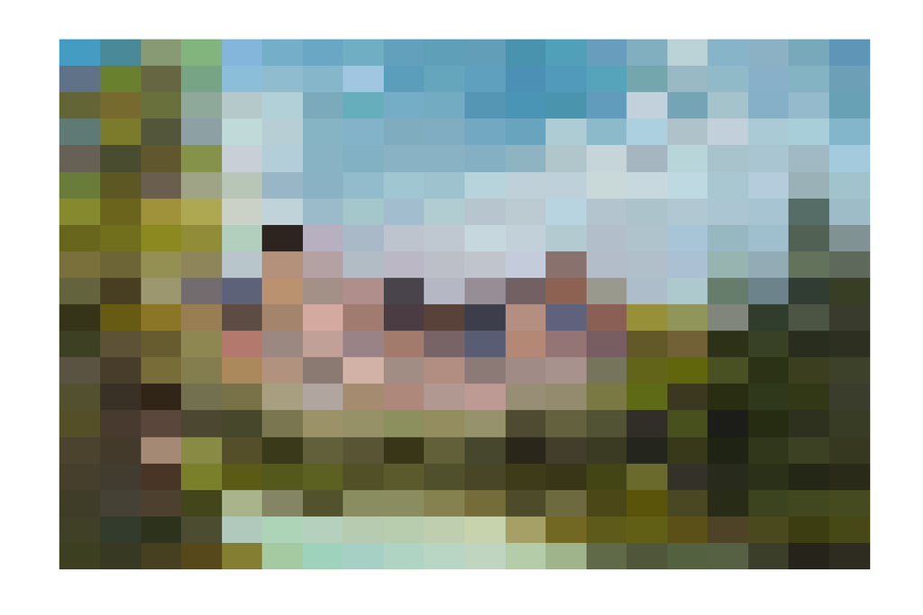

# Activities

1. Read in the data. How many variables? What are the variables summarising? How many paintings are processed?
2. Conduct a hierarchical cluster analysis. Try using “Wards linkage”. Make the dendrogram, and determine how many clusters you believe it suggests. (You can use Euclidean distance, and the variables are already on a comparable scale, so it should not be necessary to standardise them.)

3. Compute the cluster statistics suite for a range of choices of cuts of the dendrogram (e.g. $k=2, ..., 10$). How many clusters would be suggested?

4. Using your best choice of $k$, run a $k$-means clustering. Compute a confusion matrix to compare the result from hierarchical with the $k$-means. Are they very similar, or quite different? (One thing that is useful to do when comparing two cluster solutions is to re-label the cluster id’s from one group so that they best match, and the larger numbers are down the diagonal of the confusion matrix.)

5. With your best solution, take a look at the paintings that fall into each group. Write a summary explaining how the clustering algorithm organised the paintings.

6. Re-do analysis by first conducting a PCA, and compute interpoint distances on the reduced set of PCs.